# Biomedical data analysis seminar protocol

## Immatriculation # 22210364

OUTLINE :

Introduction

```
- 1. Biomedical data analysis
- 2. Reproducible research
    - 2.1 Technnical challenges reproducible reserch
- 3. NCBI SRA
- 4. Conda/bioconda
- 5. Jupyterlab
```

System Setup Tasks

```
- 1. Installing Conda
- 2. Conda Channels
- 3. Conda Environments
- 4. list Environments
- 5. Fastqc
- 6. JupyterLab
- 8. Tmux
- 9. Getting started with Jupyter
```

RNA-Seq Workflow

```
- 1. File Formats
    - 1.1 Fasta
    - 1.2 Fastq
    - 1.3 GTF
    - 1.4 SAM
- 2. Obtaining Data
- 3. Quality Control(QC)
- 4. Flexbar
- 5. Alignment And Quantification
- 6. SAM File
- 7. FeatureCounts
```

The R Programming Language

Workflow Manager : SNAKEMAKE

```
- 1. Install Snakemake via Conda :
- 2. Workflows in Terms of Rules :
```

# Introduction:

## 1. Biomedical Data Analysis

Biomedical data analysis refers to the process of extracting meaningful insights and knowledge from large and complex sets of biomedical data. This may involve the use of various statistical, computational, and machine learning methods to analyze data from sources such as genomic sequencing, medical imaging, electronic health records, and clinical trials. The goal of biomedical data analysis is to advance our understanding of human health and disease and to inform the development of new diagnostic tools, treatments, and preventative measures. Effective biomedical data analysis requires a combination of domain expertise, technical skills, and attention to ethical considerations, as well as a commitment to reproducibility and transparency in the research process.

## 2. Reproduciable Research

Replication and reproducibility are related but distinct concepts in scientific research. Replication refers to the independent repetition of an experiment or study to confirm or validate its results. Replication is essential in science to establish the validity and reliability of research findings. Reproducibility, on the other hand, refers to the ability to reproduce the results of a study using the same data and methods as described in the original study. Reproducibility involves having access to the original data, code, and documentation, as well as being able to recreate the computational environment used in the original study. In summary, replication is the repetition of an experiment to validate its results, while reproducibility is the ability to recreate the results using the same data and methods. Both are important for establishing the credibility of scientific research.

### 2.1 Technical challenges to Reproducible Research:

There are several technical challenges to enable reproducible research:

1. Data management: The availability and accessibility of the raw data and its documentation is crucial for reproducibility.
2. Computational environment: Specifying the exact software, libraries, and their versions used in the research is important to ensure that others can recreate the results.
3. Version control: Keeping track of changes to the code and data throughout the research process is necessary to enable reproducibility.
4. Collaboration: Collaborating on research projects with others can lead to a loss of reproducibility if the project is not properly documented and managed.
5. Scalability: With the increasing size and complexity of research data and models, it can be challenging to ensure reproducibility at scale.
6. Human error: Even with the best tools and practices, human error can still occur, leading to incorrect or non-reproducible results.
7. Implementation: Implementing reproducibility effectively requires effort and expertise, as well as a culture that values and encourages reproducibility.

## 3. NCBI SRA:

NCBI SRA (Sequence Read Archive) is a database maintained by the National Center for Biotechnology Information (NCBI) that stores and provides access to raw sequencing data generated by high-throughput sequencing platforms, such as Illumina, PacBio, and Oxford Nanopore. It is one of the largest public repositories of DNA and RNA sequencing data, with over 160 billion reads stored as of 2021.

Researchers can use the NCBI SRA to access data from a variety of organisms, including humans, plants, animals, and microbes. The data in the NCBI SRA can be used for a variety of purposes, including genome assembly, gene expression analysis, variant discovery, and more.

The NCBI SRA is designed to be a resource for the scientific community, and data can be freely downloaded and used for research purposes. The NCBI SRA also provides tools for analyzing the data, such as the SRA Toolkit, which allows users to download and process raw sequencing data from the NCBI SRA.

## 4. Conda/biodonda:

Conda is an open-source package management system and environment management system that can be used for installing and managing packages and dependencies for multiple programming languages, including Python and R. It was developed to provide a more efficient and user-friendly alternative to traditional package management tools, such as pip and apt-get.

BioConda is a channel within the conda package manager that specializes in bioinformatics software. It provides a collection of pre-compiled and tested open-source bioinformatics software, making it easier for bioinformaticians to install and manage these tools on their local systems. BioConda packages are frequently updated to ensure compatibility with the latest versions of software and to address any security vulnerabilities.

Conda and BioConda can be used together to manage a bioinformatics software environment, allowing users to install and manage packages, dependencies, and software versions in a consistent and reproducible manner. This can be particularly useful for bioinformatics pipelines, where software compatibility and reproducibility are critical factors.

## 5 JupyterLab:

JupyterLab is a comprehensive and innovative web-based platform for scientific computing and data science. It is designed to provide users with a modern, flexible, and powerful environment for working with Jupyter notebooks, code, and data. JupyterLab is built on the foundation of the Jupyter Notebook, which is a widely used tool for data exploration, analysis, and visualization.

With its ability to run on a local machine, remote server, or in the cloud, JupyterLab provides users with a flexible and accessible platform for data science and scientific computing. Its feature-rich environment, combined with its versatility and accessibility, makes JupyterLab an ideal tool for a wide range of data-driven applications.

# System Setup Tasks:

## 1. Installing Conda:

Steps for installing conda on linux as mentioned in the official [documentation](https://docs.conda.io/projects/conda/en/latest/user-guide/install/linux.html) of conda.

1. Open the terminal window on Linux machine (remote or local)
2. Download the latest version of miniconda using the following command `wget https://repo.anaconda.com/miniconda/Miniconda3-latest-Linux-x86_64.sh`
3. Install the downloaded miniconda file with the following command `bash Miniconda3-latest-Linux-x86_64.sh`
4. This will prompt on-screen installation instructions. Simply follow them to complete the installation process. Don't forget to initialize the conda in the installation process.
5. To verify that installation process of successful, check the version of the conda with the following command `conda --version`

## 2. Conda Channels:

In the context of the package management system of Conda, channels are designated sources of packages that are hosted and managed by organizations or individuals. These channels serve as a means to distribute and share packages to users in a centralized manner. Channels can contain packages that are either built by the channel maintainers or built by users and then submitted to the channel for distribution. The packages available within a channel are updated and managed by the channel maintainers to ensure the quality and consistency of the packages. By default, Conda provides access to the defaults channel, but users can also add additional channels as per their needs by using the conda config command.

We need to add two channels *bioconda* and *conda-forge* with the following commands.

`conda config --add channels bioconda`

`conda config --add channels conda-forge`

```python
%%bash
conda --version
```

```
conda 22.9.0
```

## 3. Conda Environments:

A conda environment is an isolated and separate environment within a conda installation that has its own set of packages and dependencies, which can be different from the base installation. This allows to create multiple environments, each with its own set of packages, which can be useful for different projects that may require different packages or different versions of packages. This way, different projects are isolated and not interfere with each other. The use of conda environments helps with package management, version control, and reproducibility.

In order to proceed with system setup tasks, we need to a new environment with the name ”bio” with a Python version of 3.9. For this we use the following command:

`conda create --name bio python=3.9`

## 4. Listing Environments:

Follw the on-screen instructions to complete the environment creation.The following commands can be used to check all the availabe environment on a system. This list should contain the newly made "bio" environment if the installation was succesfull.

```python
%%bash
conda env list
```

```
# conda environments:
#
base                     /home/ubuntu/miniconda3
bio                   *  /home/ubuntu/miniconda3/envs/bio
```

In order to activate the newly made bio environment, the following command is used:

`conda activate bio`

To deactivate this environment and go back to the base envirnoment, the following command is used:

`conda deactivate`

We can check the content of the Linux PATH variable of both *base* and *bio* environments to check what is different in them. To check the content of the PATH variable of the base environment, we first need to be in the *base* envirnoment and then need to execute the following command:

`echo $PATH`

Here is the results for my system. /home/ms04364/workbench/commands:/home/ms04364/miniconda3/bin:/usr/condabin:/usr/local/sbin: /usr/local/bin:/usr/bin:/opt/cuda/bin:/opt/cuda/nsight_compute:/opt/cuda/nsight_systems/bin: /usr/lib/jvm/default/bin:/usr/bin/site_perl:/usr/bin/vendor_perl:/usr/bin/core_perl:/home/share

Then, the *bio* environment needs to be activated with a command mentioned previously. After activating the environment, the content of the PATH variable is displayed with `echo $PATH`. Here is the content for my envirnoment. /home/ms04364/workbench/commands:/home/ms04364/.conda/envs/bio/bin:/usr/condabin:/usr/local/sbin: /usr/local/bin:/usr/bin:/opt/cuda/bin:opt/cuda/nsight_compute:/opt/cuda/nsight_systems/bin: /usr/lib/jvm/default/bin:/usr/bin/site_perl:/usr/bin/vendor_perl:/usr/bin/core_perl:/home/share

The directory for executable for the **base** environment is **"/home/ms04364/miniconda3/bin"** which is different from that of **bio** **"/home/ms04364/.conda/envs/bio/bin"**. The consequence of this change in PATH is that when the **bio** environment is activated, executables installed in that environment will take precedence over executables in the **base** environment when executing commands. This allows for isolated and controlled environments to be created, with different dependencies and executables.

## 5. Fastqc:

FastQC is a quality control tool for high throughput sequence data. To install fastqc, we first need to activate **bio** environment and then use the following command:

`conda install -c bioconda fastqc`

Follow the on-screen insturctions to complete the installation. To check the installation was succesful, we use the following command.

```python
!fastqc -h
```

```
            FastQC - A high throughput sequence QC analysis tool

SYNOPSIS

	fastqc seqfile1 seqfile2 .. seqfileN

    fastqc [-o output dir] [--(no)extract] [-f fastq|bam|sam]
           [-c contaminant file] seqfile1 .. seqfileN

DESCRIPTION

    FastQC reads a set of sequence files and produces from each one a quality
    control report consisting of a number of different modules, each one of
    which will help to identify a different potential type of problem in your
    data.

    If no files to process are specified on the command line then the program
    will start as an interactive graphical application.  If files are provided
    on the command line then the program will run with no user interaction
    required.  In this mode it is suitable for inclusion into a standardised
    analysis pipeline.

    The options for the program as as follows:

    -h --help       Print this help file and exit

    -v --version    Print the version of the program and exit

    -o --outdir     Create all output files in the specified output directory.
                    Please note that this directory must exist as the program
                    will not create it.  If this option is not set then the
                    output file for each sequence file is created in the same
                    directory as the sequence file which was processed.

    --casava        Files come from raw casava output. Files in the same sample
                    group (differing only by the group number) will be analysed
                    as a set rather than individually. Sequences with the filter
                    flag set in the header will be excluded from the analysis.
                    Files must have the same names given to them by casava
                    (including being gzipped and ending with .gz) otherwise they
```

[output cut: 64 more lines]

```

   -k --kmers       Specifies the length of Kmer to look for in the Kmer content
                    module. Specified Kmer length must be between 2 and 10. Default
                    length is 7 if not specified.

   -q --quiet       Supress all progress messages on stdout and only report errors.

   -d --dir         Selects a directory to be used for temporary files written when
                    generating report images. Defaults to system temp directory if
                    not specified.

BUGS

    Any bugs in fastqc should be reported either to simon.andrews@babraham.ac.uk
    or in www.bioinformatics.babraham.ac.uk/bugzilla/
```

## 6. JupyterLab:

JupyterLab is a comprehensive and innovative web-based platform for scientific computing and data science. It is designed to provide users with a modern, flexible, and powerful environment for working with Jupyter notebooks, code, and data. JupyterLab is built on the foundation of the Jupyter Notebook, which is a widely used tool for data exploration, analysis, and visualization.

With its ability to run on a local machine, remote server, or in the cloud, JupyterLab provides users with a flexible and accessible platform for data science and scientific computing. Its feature-rich environment, combined with its versatility and accessibility, makes JupyterLab an ideal tool for a wide range of data-driven applications.

To install jupyterlab in the **bio** envirnoment, the follwoing command is used:

`conda install -c conda-forge jupyterlab`

Follow the on-screen instructions to compelete the installation.

This step is followed by installing jupyter kernel for bash with the following command.

`conda install -c conda-forge bash_kernel`

## 7. Viewing list of Packages in an Envirnoment:

If the environment is not activated, in terminal window then the following command is used:

`conda list -n bio`

if the environment is activated in terminal window then the follwoing command is used:

```python
!conda list
```

```
# packages in environment at /home/ubuntu/miniconda3/envs/bio:
#
# Name                    Version                   Build  Channel
_libgcc_mutex             0.1                        main
_openmp_mutex             5.1                       1_gnu
aioeasywebdav             2.4.0           py39hf3d152e_1001    conda-forge
aiohttp                   3.8.1            py39hb9d737c_1    conda-forge
aiosignal                 1.3.1              pyhd8ed1ab_0    conda-forge
amply                     0.1.5              pyhd8ed1ab_0    conda-forge
anyio                     3.6.2              pyhd8ed1ab_0    conda-forge
appdirs                   1.4.4              pyh9f0ad1d_0    conda-forge
argon2-cffi               21.3.0             pyhd8ed1ab_0    conda-forge
argon2-cffi-bindings      21.2.0           py39hb9d737c_2    conda-forge
asttokens                 2.0.8              pyhd8ed1ab_0    conda-forge
async-timeout             4.0.2              pyhd8ed1ab_0    conda-forge
attmap                    0.13.2             pyhd8ed1ab_0    conda-forge
attrs                     22.1.0             pyh71513ae_1    conda-forge
babel                     2.10.3             pyhd8ed1ab_0    conda-forge
backcall                  0.2.0              pyh9f0ad1d_0    conda-forge
backports                 1.0                        py_2    conda-forge
backports.functools_lru_cache 1.6.4              pyhd8ed1ab_0    conda-forge
bash                      5.1.16               hd863ed2_0    conda-forge
bash_kernel               0.8.0              pyh1a96a4e_1    conda-forge
bcrypt                    3.2.2            py39hb9d737c_0    conda-forge
beautifulsoup4            4.11.1             pyha770c72_0    conda-forge
blas                      1.0                    openblas
bleach                    5.0.1              pyhd8ed1ab_0    conda-forge
boto3                     1.26.35            pyhd8ed1ab_0    conda-forge
botocore                  1.29.35            pyhd8ed1ab_0    conda-forge
bottleneck                1.3.5            py39h7deecbd_0
brotlipy                  0.7.0           py39hb9d737c_1004    conda-forge
bzip2                     1.0.8                h7f98852_4    conda-forge
c-ares                    1.18.1               h7f98852_0    conda-forge
ca-certificates           2022.12.7            ha878542_0    conda-forge
cachetools                5.2.0              pyhd8ed1ab_0    conda-forge
certifi                   2022.12.7          pyhd8ed1ab_0    conda-forge
cffi                      1.15.1           py39h74dc2b5_0
charset-normalizer        2.1.1              pyhd8ed1ab_0    conda-forge
coincbc                   2.10.5               hcee13e7_1    conda-forge
colorama                  0.4.6              pyhd8ed1ab_0    conda-forge
```

[output cut: 174 more lines]

```
uritemplate               4.1.1              pyhd8ed1ab_0    conda-forge
urllib3                   1.26.11            pyhd8ed1ab_0    conda-forge
veracitools               0.1.3                      py_0    conda-forge
wcwidth                   0.2.5              pyh9f0ad1d_2    conda-forge
webencodings              0.5.1                      py_1    conda-forge
websocket-client          1.4.1              pyhd8ed1ab_0    conda-forge
wheel                     0.37.1             pyhd3eb1b0_0
wrapt                     1.14.1           py39hb9d737c_0    conda-forge
xz                        5.2.6                h5eee18b_0
yaml                      0.2.5                h7f98852_2    conda-forge
yarl                      1.7.2            py39hb9d737c_2    conda-forge
yte                       1.5.1            py39hf3d152e_1    conda-forge
zeromq                    4.3.4                h9c3ff4c_1    conda-forge
zipp                      3.10.0             pyhd8ed1ab_0    conda-forge
zlib                      1.2.13               h5eee18b_0
```

## 8. Connect JupyterLab and R:

In order to run the current R, it needs to be installed and connected with Jupyter. For this, the **bio** environment needs to be activated and then the following command needs to be executed:

`R -e "IRkernel::installspec()`

## 9. Start A Jupyter Server:

A new Jupyter server needs to configured and started. The server is configured with the following commands.

`jupyter server --generate-config`

`jupyter server password`

The terminal would ask for a password. Type a unique password and remember it for future use. After confirming the password, start a new server by typing the following command:

`jupyter lab --no-browser --ip "*"`

## 10. Connect To A Remote Jupyter Server:

To access the Jupyter server on a remote machine, we need to set up port forwarding. This involves redirecting requests to the remote machine. To establish the forwarding, we need to open a new terminal in Windows and make an ssh connection using a different command that includes the "-L" option. The following needs to be executed by replacing the "x" with correct ip and also replacing the path with correct key path.

`ssh -i /path/to/your/keyfile -L 8888:localhost:8888 ubuntu@xxx.xxx.xxx.xxx`

Any request to your local port 8888 is forwarded via a secure connection to localhost:8888 at the specified remote machine. To connect to the jupyter server, open a new browser and type in the address **localhost:8888** and press enter. The jupyter server should be accessiable through this link now. This way of connecting to Jupter Sever faces two problems though.

1. The jupyter server is running on terminal so if we the terminal is closed or the connection terminated/interrupted, the jupyter server would stop running.
2. The runing jupyter server is occupying the terminal. Therefore, working in parallel on terminal is not possiable.

**Tmux** can help solve these problems.

## 10. Tmux:

Tmux is a terminal multiplexer. It lets you switch easily between several programs in one terminal, detach them (they keep running in the background) and reattach them to a different terminal. This can solve the problems mentioned in the last topic. Therefore, Tmux needs to be installed in the **base** conda envirnoment with the following command:

`conda install tmux`

Follow the on-screen insturctions to complete the installation.

A session with specified name can be created by using the following comman where the **specific_name** needs to be replace with desirable session name.

`tmux new -s specific_name`

This command creates a new tmux session, in order to detach from this session the following command is used:

`tmux detach`

Multiple tmux sessions can be created by using different specific names for the command introduced. An example of this would be.

`tmux new -s specific_name2`

This new session can be detached with `tmux detach` and the first session can then be attached with the following command:

`tmux a -t specific_name`

Here the *-t* option/flag is for specifiying the target session whereas *a* lets the terminal know that the specified session needs to be attached.

Multiple panes within a session can be created, to create and switch between multiple panes in a terminal multiplexer like tmux, you can use the following commands:

Create panes:

`Ctrl + b followed by %` - to split the pane vertically. `Ctrl + b followed by "` - to split the pane horizontally.

Switch panes:

`Ctrl + b followed by Arrow keys` - to navigate between panes. `Ctrl + b followed by l or h` - to move to the next or previous pane, respectively.

Ctrl + b is the tmux prefix, and need to be pressed before entering any tmux command.

In the context of **tmux**, the following terms have specific meanings:

**Session:** A tmux session is a persistent environment in which you can run multiple windows, each containing one or more panes. A tmux session can be detached and reattached later, which allows you to persist your terminal environment even after you've logged out of your machine.

**Window:** A tmux window is a single terminal environment within a tmux session. It contains one or more panes and acts as a container for these panes. You can switch between windows within a tmux session to access different terminal environments.

**Pane:** A tmux pane is a single terminal instance within a tmux window. You can split a tmux window into multiple panes to run multiple terminal sessions side-by-side within a single window. You can switch between panes within a window to access different terminal sessions.

In summary, tmux provides a hierarchical organization of terminal sessions, where a session can contain multiple windows, each containing one or more panes.

Now to make a jupyter session that will always run even if we close the terminal. This final steps needs execution.

1. Create a new tmux session with the name ”jserver”. Activate the ”bio” environment in that newly generated tmux session. Start the Jupyter server in that session. Detach from the session.
2. Open a browser and try to connect to your Jupyter server.

## 11. Getting started with Jupyter:

Jupyter supports Markdown, a lightweight markup language that you can use to add formatting elements to plaintext text documents. It is one of the most popular markup language. Markdown syntax allows for the formatting of text by modifying the text in a specific way based on the syntax used

**Headings**: Headings can be created with using '#' syntax before the text that needs to be included in the headings. The size of the headings can be adjusted by using a different counts of '#'. Higher the count, lower the heading size is genral.

**Bold/italic**: The text can be made italic by writing it between two '*' i.e having a asteriks at the either side of the text. The text can be made bold by placing two '**' at the start and '**' at the end of the text i.e writing the text between two stars at the either side of the text.The text can be made both bold and italic using three asteriks at the both ends of the text.

**Numbered/unnumbered lists**: To create numbered list enter "1." followed by space. The language itself turn the text to a numbered list. For the second element of the list, "2." needs to be entered to add that element to list. This repeatedly accordingly for other elements of the list. To create a unnumbered lists/circular bullet point, use one of the following methods. Each bullet point must be on its own line.

- A hyphen (-) followed by one or two spaces, for example: - Bulleted item
- A space, a hyphen (-) and a space, for example: - Bulleted item
- An asterisk (*) followed by one or two spaces, for example:* Bulleted item

**Block qoute**: For creating block qoute, the text on a separate/new line should starts with greater than symbol '>' followed by space and the result would look like something like below.

> This is block quote

**Tables**: To add a table, use three or more hyphens (---) to create each column’s header, and use pipes (|) to separate each column. For compatibility, a pipe is added to either end of the row. Here is an example table created from the follwing text "**| Number of steps | NGS analysis| |---| ---| | Variant discovery | 14 |**"

| Number of steps | NGS analysis |
| --- | --- |
| Variant discovery | 14 |

**Footnotes**: Footnotes can not be created in jupyter notebook. Special plugin Jekyll is used for it.

## RNA-Seq Workflow:

Abstracting from the whole wet lab part, the overall goal of the laboratory part is to obtain accurate sequence data. Accurate means that both, the sequence information itself (the nucleotides) as well as the quantification of the sequences shall be as precise and bias-free as possible. Sequence information can be obtained by various sequencing technologies (Illumina, PacBio, Oxford Nanopore) and different sources (WGS, Exom-seq, RNA-seq, ChIP-seq, CLIP, etc.).

The diagram below shows the workflow from RNA-seq data to differential expression analysis

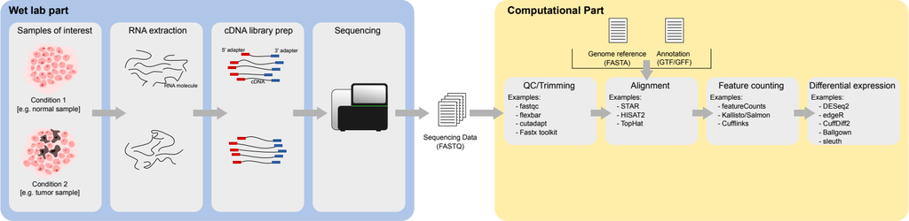

Besides sequencing data a reference genome and the corresponding annotation is needed to perform a typical differential expression analysis.

### 1. File Formats:

#### 1. Fasta:

The FASTA file format is a text-based format storing either nucleotide or protein sequences. The ">" specifies a new sequence entry and it is typically followed by an identifier and additional information about the sequence and example fast file is shown below

> >crab_anapl ALPHA CRYSTALLIN B CHAIN (ALPHA(B)-CRYSTALLIN).

MDITIHNPLIRRPLFSWLAPSRIFDQIFGEHLQESELLPASPSLSPFLMR SPIFRMPSWLETGLSEMRLEKDKFSVNLDVKHFSPEELKVKVLGDMVEIH GKHEERQDEHGFIAREFNRKYRIPADVDPLTITSSLSLDGVLTVSAPRKQ SDVPERSIPITREEKPAIAGAQRK

#### 2. FASTQ:

It is another text-based format of storing nucleotide sequence information and is typically the format in which DNA sequencing machines output there data. It stores sequence information as well as have quality scores for each nucleotide. A typical entry of the **fastq** file have four lines.

1. "@" followed by the sequence identifier and the additional information of the sequence.
2. The second line has the sequence of nucleotides.
3. A line that separates the sequence from quality score called the separator line that has a "+" sign on it and nothing else.
4. A quality score in ASCII format for each nucleotide.

> @SEQ_ID

> GATTTGGGGTTCAAAGCAGTATCGATCAAATAGTAAATCCATTTGTTCAACTCACAGTTT

> +

> !''*((((***+))%%%++)(%%%%).1***-+*''))**55CCF>>>>>>CCCCCCC65

#### 3. GTF:

A file format called Gene Transfer Format (GTF) is used to store details about the structure of genes. It is a tab-delimited text format that is based on the general feature format (GFF), but it includes a few extra conventions that are unique to gene information. It has 9 columns eight of which are the same as GGG. An important GTF characteristic that may be evaluated is the ability to verify the format given a sequence and a GTF file. This considerably lessens issues with data sharing between groups.

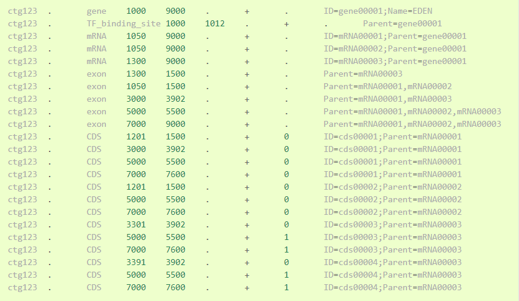

### 2. Obtaining Data:

The data for RNA-seq analysis in this workflow is downloaded from the links shown in the links below.

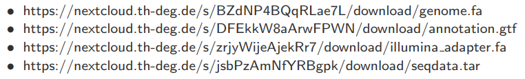

The `wget` command that retrieves content from web servers was used followed by the links shown above were used to download the data for this workflow.

**Tape archives (tar):** Tape archives are created and extracted using the Linux command "tar" which stands for tape archive. One of the crucial commands in Linux that provide archiving functionality is the tar command. Compressed or uncompressed Archive files can be created, maintained, and modified using the Linux tar program. The following command is used to uncompressed the seqdata downloaded in the previous step:

```python
!tar -xvf seqdata.tar -C /home/ubuntu/seqdata
```

```
G1_rep1_read1.fastq.gz
G1_rep1_read2.fastq.gz
G1_rep2_read1.fastq.gz
G1_rep2_read2.fastq.gz
G1_rep3_read1.fastq.gz
G1_rep3_read2.fastq.gz
G2_rep1_read1.fastq.gz
G2_rep1_read2.fastq.gz
G2_rep2_read1.fastq.gz
G2_rep2_read2.fastq.gz
G2_rep3_read1.fastq.gz
G2_rep3_read2.fastq.gz
```

The **-x** flag in this command extracts file from an archive. The **-v** flag verbosely lists the which are processed. The **-f** flag use archive file whereas the **-C** option is to specify the path of the directory to which the files are being extracted. This gives us 12 files for the data used in the current analysis.

### 3. Quality Control(QC):

To determine quality of the raw sequencing data, quality control is performed. In order to organize the qc report for all of the seqdata files, new directory **fastqc** is created and then the following command is performed to obtain the qc report:

```python
%%bash
fastqc /home/ubuntu/seqdata/G1_rep1_read1.fastq.gz -o /home/ubuntu/seqdata/fastqc
fastqc /home/ubuntu/seqdata/G1_rep1_read2.fastqc.gz -o /home/ubuntu/seqdata/fastqc
fastqc /home/ubuntu/seqdata/G1_rep2_read1.fastq.gz -o /home/ubuntu/seqdata/fastqc
fastqc /home/ubuntu/seqdata/G1_rep2_read2.fastq.gz -o /home/ubuntu/seqdata/fastqc
fastqc /home/ubuntu/seqdata/G1_rep3_read1.fastq.gz -o /home/ubuntu/seqdata/fastqc
fastqc /home/ubuntu/seqdata/G1_rep3_read2.fastq.gz -o /home/ubuntu/seqdata/fastqc
fastqc /home/ubuntu/seqdata/G2_rep1_read1.fastq.gz -o /home/ubuntu/seqdata/fastqc
fastqc /home/ubuntu/seqdata/G2_rep1_read2.fastq.gz -o /home/ubuntu/seqdata/fastqc
fastqc /home/ubuntu/seqdata/G2_rep2_read1.fastq.gz -o /home/ubuntu/seqdata/fastqc
fastqc /home/ubuntu/seqdata/G2_rep2_read2.fastq.gz -o /home/ubuntu/seqdata/fastqc
fastqc /home/ubuntu/seqdata/G2_rep3_read1.fastq.gz -o /home/ubuntu/seqdata/fastqc
fastqc /home/ubuntu/seqdata/G2_rep3_read2.fastq.gz -o /home/ubuntu/seqdata/fastqc
```

```
Started analysis of G1_rep1_read1.fastq.gz
Approx 5% complete for G1_rep1_read1.fastq.gz
Approx 10% complete for G1_rep1_read1.fastq.gz
Approx 15% complete for G1_rep1_read1.fastq.gz
Approx 20% complete for G1_rep1_read1.fastq.gz
Approx 25% complete for G1_rep1_read1.fastq.gz
Approx 30% complete for G1_rep1_read1.fastq.gz
Approx 35% complete for G1_rep1_read1.fastq.gz
Approx 40% complete for G1_rep1_read1.fastq.gz
Approx 45% complete for G1_rep1_read1.fastq.gz
Approx 50% complete for G1_rep1_read1.fastq.gz
Approx 55% complete for G1_rep1_read1.fastq.gz
Approx 60% complete for G1_rep1_read1.fastq.gz
Approx 65% complete for G1_rep1_read1.fastq.gz
Approx 70% complete for G1_rep1_read1.fastq.gz
Approx 75% complete for G1_rep1_read1.fastq.gz
Approx 80% complete for G1_rep1_read1.fastq.gz
Approx 85% complete for G1_rep1_read1.fastq.gz
Approx 90% complete for G1_rep1_read1.fastq.gz
Approx 95% complete for G1_rep1_read1.fastq.gz
```

```
Analysis complete for G1_rep1_read1.fastq.gz
```

```
Skipping '/home/ubuntu/seqdata/G1_rep1_read2.fastqc.gz' which didn't exist, or couldn't be read
Started analysis of G1_rep2_read1.fastq.gz
Approx 5% complete for G1_rep2_read1.fastq.gz
Approx 10% complete for G1_rep2_read1.fastq.gz
Approx 15% complete for G1_rep2_read1.fastq.gz
Approx 20% complete for G1_rep2_read1.fastq.gz
Approx 25% complete for G1_rep2_read1.fastq.gz
Approx 30% complete for G1_rep2_read1.fastq.gz
Approx 35% complete for G1_rep2_read1.fastq.gz
Approx 40% complete for G1_rep2_read1.fastq.gz
Approx 45% complete for G1_rep2_read1.fastq.gz
Approx 50% complete for G1_rep2_read1.fastq.gz
Approx 55% complete for G1_rep2_read1.fastq.gz
Approx 60% complete for G1_rep2_read1.fastq.gz
Approx 65% complete for G1_rep2_read1.fastq.gz
Approx 70% complete for G1_rep2_read1.fastq.gz
Approx 75% complete for G1_rep2_read1.fastq.gz
Approx 80% complete for G1_rep2_read1.fastq.gz
Approx 85% complete for G1_rep2_read1.fastq.gz
Approx 90% complete for G1_rep2_read1.fastq.gz
Approx 95% complete for G1_rep2_read1.fastq.gz
```

```
Analysis complete for G1_rep2_read1.fastq.gz
```

```
Started analysis of G1_rep2_read2.fastq.gz
Approx 5% complete for G1_rep2_read2.fastq.gz
Approx 10% complete for G1_rep2_read2.fastq.gz
Approx 15% complete for G1_rep2_read2.fastq.gz
Approx 20% complete for G1_rep2_read2.fastq.gz
Approx 25% complete for G1_rep2_read2.fastq.gz
Approx 30% complete for G1_rep2_read2.fastq.gz
Approx 35% complete for G1_rep2_read2.fastq.gz
Approx 40% complete for G1_rep2_read2.fastq.gz
Approx 45% complete for G1_rep2_read2.fastq.gz
Approx 50% complete for G1_rep2_read2.fastq.gz
Approx 55% complete for G1_rep2_read2.fastq.gz
Approx 60% complete for G1_rep2_read2.fastq.gz
Approx 65% complete for G1_rep2_read2.fastq.gz
Approx 70% complete for G1_rep2_read2.fastq.gz
Approx 75% complete for G1_rep2_read2.fastq.gz
Approx 80% complete for G1_rep2_read2.fastq.gz
Approx 85% complete for G1_rep2_read2.fastq.gz
Approx 90% complete for G1_rep2_read2.fastq.gz
Approx 95% complete for G1_rep2_read2.fastq.gz
```

```
Analysis complete for G1_rep2_read2.fastq.gz
```

```
Started analysis of G1_rep3_read1.fastq.gz
Approx 5% complete for G1_rep3_read1.fastq.gz
Approx 10% complete for G1_rep3_read1.fastq.gz
Approx 15% complete for G1_rep3_read1.fastq.gz
Approx 20% complete for G1_rep3_read1.fastq.gz
Approx 25% complete for G1_rep3_read1.fastq.gz
Approx 30% complete for G1_rep3_read1.fastq.gz
Approx 35% complete for G1_rep3_read1.fastq.gz
Approx 40% complete for G1_rep3_read1.fastq.gz
Approx 45% complete for G1_rep3_read1.fastq.gz
Approx 50% complete for G1_rep3_read1.fastq.gz
Approx 55% complete for G1_rep3_read1.fastq.gz
Approx 60% complete for G1_rep3_read1.fastq.gz
Approx 65% complete for G1_rep3_read1.fastq.gz
Approx 70% complete for G1_rep3_read1.fastq.gz
Approx 75% complete for G1_rep3_read1.fastq.gz
Approx 80% complete for G1_rep3_read1.fastq.gz
Approx 85% complete for G1_rep3_read1.fastq.gz
Approx 90% complete for G1_rep3_read1.fastq.gz
Approx 95% complete for G1_rep3_read1.fastq.gz
```

```
Analysis complete for G1_rep3_read1.fastq.gz
```

```
Started analysis of G1_rep3_read2.fastq.gz
Approx 5% complete for G1_rep3_read2.fastq.gz
Approx 10% complete for G1_rep3_read2.fastq.gz
Approx 15% complete for G1_rep3_read2.fastq.gz
Approx 20% complete for G1_rep3_read2.fastq.gz
Approx 25% complete for G1_rep3_read2.fastq.gz
Approx 30% complete for G1_rep3_read2.fastq.gz
Approx 35% complete for G1_rep3_read2.fastq.gz
Approx 40% complete for G1_rep3_read2.fastq.gz
Approx 45% complete for G1_rep3_read2.fastq.gz
Approx 50% complete for G1_rep3_read2.fastq.gz
Approx 55% complete for G1_rep3_read2.fastq.gz
Approx 60% complete for G1_rep3_read2.fastq.gz
Approx 65% complete for G1_rep3_read2.fastq.gz
Approx 70% complete for G1_rep3_read2.fastq.gz
Approx 75% complete for G1_rep3_read2.fastq.gz
Approx 80% complete for G1_rep3_read2.fastq.gz
Approx 85% complete for G1_rep3_read2.fastq.gz
Approx 90% complete for G1_rep3_read2.fastq.gz
Approx 95% complete for G1_rep3_read2.fastq.gz
```

```
Analysis complete for G1_rep3_read2.fastq.gz
```

```
Started analysis of G2_rep1_read1.fastq.gz
Approx 5% complete for G2_rep1_read1.fastq.gz
Approx 10% complete for G2_rep1_read1.fastq.gz
Approx 15% complete for G2_rep1_read1.fastq.gz
Approx 20% complete for G2_rep1_read1.fastq.gz
Approx 25% complete for G2_rep1_read1.fastq.gz
Approx 30% complete for G2_rep1_read1.fastq.gz
Approx 35% complete for G2_rep1_read1.fastq.gz
Approx 40% complete for G2_rep1_read1.fastq.gz
Approx 45% complete for G2_rep1_read1.fastq.gz
Approx 50% complete for G2_rep1_read1.fastq.gz
Approx 55% complete for G2_rep1_read1.fastq.gz
Approx 60% complete for G2_rep1_read1.fastq.gz
Approx 65% complete for G2_rep1_read1.fastq.gz
Approx 70% complete for G2_rep1_read1.fastq.gz
Approx 75% complete for G2_rep1_read1.fastq.gz
Approx 80% complete for G2_rep1_read1.fastq.gz
Approx 85% complete for G2_rep1_read1.fastq.gz
Approx 90% complete for G2_rep1_read1.fastq.gz
Approx 95% complete for G2_rep1_read1.fastq.gz
```

```
Analysis complete for G2_rep1_read1.fastq.gz
```

```
Started analysis of G2_rep1_read2.fastq.gz
Approx 5% complete for G2_rep1_read2.fastq.gz
Approx 10% complete for G2_rep1_read2.fastq.gz
Approx 15% complete for G2_rep1_read2.fastq.gz
Approx 20% complete for G2_rep1_read2.fastq.gz
Approx 25% complete for G2_rep1_read2.fastq.gz
Approx 30% complete for G2_rep1_read2.fastq.gz
Approx 35% complete for G2_rep1_read2.fastq.gz
Approx 40% complete for G2_rep1_read2.fastq.gz
Approx 45% complete for G2_rep1_read2.fastq.gz
Approx 50% complete for G2_rep1_read2.fastq.gz
Approx 55% complete for G2_rep1_read2.fastq.gz
Approx 60% complete for G2_rep1_read2.fastq.gz
Approx 65% complete for G2_rep1_read2.fastq.gz
Approx 70% complete for G2_rep1_read2.fastq.gz
Approx 75% complete for G2_rep1_read2.fastq.gz
Approx 80% complete for G2_rep1_read2.fastq.gz
Approx 85% complete for G2_rep1_read2.fastq.gz
Approx 90% complete for G2_rep1_read2.fastq.gz
Approx 95% complete for G2_rep1_read2.fastq.gz
```

```
Analysis complete for G2_rep1_read2.fastq.gz
```

```
Started analysis of G2_rep2_read1.fastq.gz
Approx 5% complete for G2_rep2_read1.fastq.gz
Approx 10% complete for G2_rep2_read1.fastq.gz
Approx 15% complete for G2_rep2_read1.fastq.gz
Approx 20% complete for G2_rep2_read1.fastq.gz
Approx 25% complete for G2_rep2_read1.fastq.gz
Approx 30% complete for G2_rep2_read1.fastq.gz
Approx 35% complete for G2_rep2_read1.fastq.gz
Approx 40% complete for G2_rep2_read1.fastq.gz
Approx 45% complete for G2_rep2_read1.fastq.gz
Approx 50% complete for G2_rep2_read1.fastq.gz
Approx 55% complete for G2_rep2_read1.fastq.gz
Approx 60% complete for G2_rep2_read1.fastq.gz
Approx 65% complete for G2_rep2_read1.fastq.gz
Approx 70% complete for G2_rep2_read1.fastq.gz
Approx 75% complete for G2_rep2_read1.fastq.gz
Approx 80% complete for G2_rep2_read1.fastq.gz
Approx 85% complete for G2_rep2_read1.fastq.gz
Approx 90% complete for G2_rep2_read1.fastq.gz
Approx 95% complete for G2_rep2_read1.fastq.gz
```

```
Analysis complete for G2_rep2_read1.fastq.gz
```

```
Started analysis of G2_rep2_read2.fastq.gz
Approx 5% complete for G2_rep2_read2.fastq.gz
Approx 10% complete for G2_rep2_read2.fastq.gz
Approx 15% complete for G2_rep2_read2.fastq.gz
Approx 20% complete for G2_rep2_read2.fastq.gz
Approx 25% complete for G2_rep2_read2.fastq.gz
Approx 30% complete for G2_rep2_read2.fastq.gz
Approx 35% complete for G2_rep2_read2.fastq.gz
Approx 40% complete for G2_rep2_read2.fastq.gz
Approx 45% complete for G2_rep2_read2.fastq.gz
Approx 50% complete for G2_rep2_read2.fastq.gz
Approx 55% complete for G2_rep2_read2.fastq.gz
Approx 60% complete for G2_rep2_read2.fastq.gz
Approx 65% complete for G2_rep2_read2.fastq.gz
Approx 70% complete for G2_rep2_read2.fastq.gz
Approx 75% complete for G2_rep2_read2.fastq.gz
Approx 80% complete for G2_rep2_read2.fastq.gz
Approx 85% complete for G2_rep2_read2.fastq.gz
Approx 90% complete for G2_rep2_read2.fastq.gz
Approx 95% complete for G2_rep2_read2.fastq.gz
```

```
Analysis complete for G2_rep2_read2.fastq.gz
```

```
Started analysis of G2_rep3_read1.fastq.gz
Approx 5% complete for G2_rep3_read1.fastq.gz
Approx 10% complete for G2_rep3_read1.fastq.gz
Approx 15% complete for G2_rep3_read1.fastq.gz
Approx 20% complete for G2_rep3_read1.fastq.gz
Approx 25% complete for G2_rep3_read1.fastq.gz
Approx 30% complete for G2_rep3_read1.fastq.gz
Approx 35% complete for G2_rep3_read1.fastq.gz
Approx 40% complete for G2_rep3_read1.fastq.gz
Approx 45% complete for G2_rep3_read1.fastq.gz
Approx 50% complete for G2_rep3_read1.fastq.gz
Approx 55% complete for G2_rep3_read1.fastq.gz
Approx 60% complete for G2_rep3_read1.fastq.gz
Approx 65% complete for G2_rep3_read1.fastq.gz
Approx 70% complete for G2_rep3_read1.fastq.gz
Approx 75% complete for G2_rep3_read1.fastq.gz
Approx 80% complete for G2_rep3_read1.fastq.gz
Approx 85% complete for G2_rep3_read1.fastq.gz
Approx 90% complete for G2_rep3_read1.fastq.gz
Approx 95% complete for G2_rep3_read1.fastq.gz
```

```
Analysis complete for G2_rep3_read1.fastq.gz
```

```
Started analysis of G2_rep3_read2.fastq.gz
Approx 5% complete for G2_rep3_read2.fastq.gz
Approx 10% complete for G2_rep3_read2.fastq.gz
Approx 15% complete for G2_rep3_read2.fastq.gz
Approx 20% complete for G2_rep3_read2.fastq.gz
Approx 25% complete for G2_rep3_read2.fastq.gz
Approx 30% complete for G2_rep3_read2.fastq.gz
Approx 35% complete for G2_rep3_read2.fastq.gz
Approx 40% complete for G2_rep3_read2.fastq.gz
Approx 45% complete for G2_rep3_read2.fastq.gz
Approx 50% complete for G2_rep3_read2.fastq.gz
Approx 55% complete for G2_rep3_read2.fastq.gz
Approx 60% complete for G2_rep3_read2.fastq.gz
Approx 65% complete for G2_rep3_read2.fastq.gz
Approx 70% complete for G2_rep3_read2.fastq.gz
Approx 75% complete for G2_rep3_read2.fastq.gz
Approx 80% complete for G2_rep3_read2.fastq.gz
Approx 85% complete for G2_rep3_read2.fastq.gz
Approx 90% complete for G2_rep3_read2.fastq.gz
Approx 95% complete for G2_rep3_read2.fastq.gz
```

```
Analysis complete for G2_rep3_read2.fastq.gz
```

The **-o** flag/option followed by the path specifies the directory in which the qc reports needs to be generated.

This quality control step on raw sequencing data is important because in addition to highlighting data concerns, regulating the quality of raw data makes it easier to immediately identify low-quality samples. This frequently entails significant time savings during further analysis.

[figure not shown]

### 4. Flexbar:

Data from high-throughput sequencing are efficiently preprocessed using the application Flexbar. Barcoded runs are demultiplexed, and adapter sequences are eliminated. There are a number of adapter removal presets for Illumina libraries. Flexbar uses multicore parallelism and SIMD to compute precise overlap alignments. In addition, features for trimming and filtering are included, such as trimming of homopolymers at read ends. Flexbar boosts genome and transcriptome assembly and read mapping rates. A flexible method can be used to derive distinctive molecular IDs. Data in the fasta and fastq formats from several sequencing platforms are supported by the software.

Flexbar is installed in the **bio** environment of conda using the following command: `conda install -c bioconda flexbar`

It is important for this program that the adapter sequences are at the end as flexbar only leaves the sequence that is between two adapters and discard everything else. Therefore, if the adapters are in the middel, important sequence information could be lost.

```python
%%bash
flexbar --adapter-min-overlap 7 --min-read-length 25 -x 13 -r /home/ubuntu/seqdata/G1_rep1_read1.fastq.gz -p /home/ubuntu/seqdata/G1_rep1_read2.fastq.gz -a2 /home/ubuntu/illumina_adapter.fa -t /home/ubuntu/seqdata/trimmed_seq/G1_rep1_read
flexbar --adapter-min-overlap 7 --min-read-length 25 -x 13 -r /home/ubuntu/seqdata/G1_rep2_read1.fastq.gz -p /home/ubuntu/seqdata/G1_rep2_read2.fastq.gz -a2 /home/ubuntu/illumina_adapter.fa -t /home/ubuntu/seqdata/trimmed_seq/G1_rep2_read
flexbar --adapter-min-overlap 7 --min-read-length 25 -x 13 -r /home/ubuntu/seqdata/G1_rep3_read1.fastq.gz -p /home/ubuntu/seqdata/G1_rep3_read2.fastq.gz -a2 /home/ubuntu/illumina_adapter.fa -t /home/ubuntu/seqdata/trimmed_seq/G1_rep3_read
flexbar --adapter-min-overlap 7 --min-read-length 25 -x 13 -r /home/ubuntu/seqdata/G2_rep1_read1.fastq.gz -p /home/ubuntu/seqdata/G2_rep1_read2.fastq.gz -a2 /home/ubuntu/illumina_adapter.fa -t /home/ubuntu/seqdata/trimmed_seq/G2_rep1_read
flexbar --adapter-min-overlap 7 --min-read-length 25 -x 13 -r /home/ubuntu/seqdata/G2_rep2_read1.fastq.gz -p /home/ubuntu/seqdata/G2_rep2_read2.fastq.gz -a2 /home/ubuntu/illumina_adapter.fa -t /home/ubuntu/seqdata/trimmed_seq/G2_rep2_read
flexbar --adapter-min-overlap 7 --min-read-length 25 -x 13 -r /home/ubuntu/seqdata/G2_rep3_read1.fastq.gz -p /home/ubuntu/seqdata/G2_rep3_read2.fastq.gz -a2 /home/ubuntu/illumina_adapter.fa -t /home/ubuntu/seqdata/trimmed_seq/G2_rep3_read
```

### 5. Alignment And Quantification:

STAR (Spliced Transcripts Alignment to a Reference) is a software tool for aligning RNA-seq data to a reference genome. It is widely used in transcriptome analysis due to its fast speed, high sensitivity, and ability to handle alternative splicing events.

In STAR, the RNA-seq reads are first transformed into short reads, called "seeds", which are then aligned to the reference genome. STAR then extends these alignments to full-length reads, taking into account alternative splicing events. The alignment results are used to construct a comprehensive picture of the transcriptome, including gene expression levels, alternative splice forms, and gene fusion events.

STAR also supports the use of a genome-guided mode, in which transcriptome information is used to guide the alignment of RNA-seq reads to the reference genome, leading to improved accuracy and sensitivity.

In order to install the STAR into the **bio** environment, following command is used: `conda install -c bioconda star` After installation, a new directory to store the alignment file is made and the trimmed reads generated at the last step are aligned with the reference genome using the following command:

```python
%%bash

STAR --runMode genomeGenerate --genomeDir /home/ubuntu/seqdata/mapped/ --genomeFastaFiles /home/ubuntu/smake_example/genome/genome.fa --sjdbGTFfile /home/ubuntu/smake_example/genome/annotation.gtf --genomeSAindexNbases 11 && STAR --genomeDir /home/ubuntu/seqdata/mapped/ --readFilesIn /home/ubuntu/seqdata/trimmed_seq/G1_rep1_read_1.fastq /home/ubuntu/seqdata/trimmed_seq/G1_rep1_read_2.fastq --outFileNamePrefix /home/ubuntu/seqdata/mapped/G1_rep1
STAR --runMode genomeGenerate --genomeDir /home/ubuntu/seqdata/mapped/ --genomeFastaFiles /home/ubuntu/smake_example/genome/genome.fa --sjdbGTFfile /home/ubuntu/smake_example/genome/annotation.gtf --genomeSAindexNbases 11 && STAR --genomeDir /home/ubuntu/seqdata/mapped/ --readFilesIn /home/ubuntu/seqdata/trimmed_seq/G1_rep2_read_1.fastq /home/ubuntu/seqdata/trimmed_seq/G1_rep2_read_2.fastq --outFileNamePrefix /home/ubuntu/seqdata/mapped/G1_rep2
STAR --runMode genomeGenerate --genomeDir /home/ubuntu/seqdata/mapped/ --genomeFastaFiles /home/ubuntu/smake_example/genome/genome.fa --sjdbGTFfile /home/ubuntu/smake_example/genome/annotation.gtf --genomeSAindexNbases 11 && STAR --genomeDir /home/ubuntu/seqdata/mapped/ --readFilesIn /home/ubuntu/seqdata/trimmed_seq/G1_rep3_read_1.fastq /home/ubuntu/seqdata/trimmed_seq/G1_rep3_read_2.fastq --outFileNamePrefix /home/ubuntu/seqdata/mapped/G1_rep3
STAR --runMode genomeGenerate --genomeDir /home/ubuntu/seqdata/mapped/ --genomeFastaFiles /home/ubuntu/smake_example/genome/genome.fa --sjdbGTFfile /home/ubuntu/smake_example/genome/annotation.gtf --genomeSAindexNbases 11 && STAR --genomeDir /home/ubuntu/seqdata/mapped/ --readFilesIn /home/ubuntu/seqdata/trimmed_seq/G2_rep1_read_1.fastq /home/ubuntu/seqdata/trimmed_seq/G2_rep1_read_2.fastq --outFileNamePrefix /home/ubuntu/seqdata/mapped/G2_rep1
STAR --runMode genomeGenerate --genomeDir /home/ubuntu/seqdata/mapped/ --genomeFastaFiles /home/ubuntu/smake_example/genome/genome.fa --sjdbGTFfile /home/ubuntu/smake_example/genome/annotation.gtf --genomeSAindexNbases 11 && STAR --genomeDir /home/ubuntu/seqdata/mapped/ --readFilesIn /home/ubuntu/seqdata/trimmed_seq/G2_rep2_read_1.fastq /home/ubuntu/seqdata/trimmed_seq/G2_rep2_read_2.fastq --outFileNamePrefix /home/ubuntu/seqdata/mapped/G2_rep2
STAR --runMode genomeGenerate --genomeDir /home/ubuntu/seqdata/mapped/ --genomeFastaFiles /home/ubuntu/smake_example/genome/genome.fa --sjdbGTFfile /home/ubuntu/smake_example/genome/annotation.gtf --genomeSAindexNbases 11 && STAR --genomeDir /home/ubuntu/seqdata/mapped/ --readFilesIn /home/ubuntu/seqdata/trimmed_seq/G2_rep3_read_1.fastq /home/ubuntu/seqdata/trimmed_seq/G2_rep3_read_2.fastq --outFileNamePrefix /home/ubuntu/seqdata/mapped/G2_rep3
```

```
Feb 03 21:21:25 ..... started STAR run
Feb 03 21:21:25 ... starting to generate Genome files
Feb 03 21:21:27 ... starting to sort Suffix Array. This may take a long time...
Feb 03 21:21:27 ... sorting Suffix Array chunks and saving them to disk...
Feb 03 21:22:13 ... loading chunks from disk, packing SA...
Feb 03 21:22:14 ... finished generating suffix array
Feb 03 21:22:14 ... generating Suffix Array index
Feb 03 21:22:16 ... completed Suffix Array index
Feb 03 21:22:16 ..... processing annotations GTF
Feb 03 21:22:16 ..... inserting junctions into the genome indices
Feb 03 21:22:26 ... writing Genome to disk ...
Feb 03 21:22:26 ... writing Suffix Array to disk ...
Feb 03 21:22:27 ... writing SAindex to disk
Feb 03 21:22:27 ..... finished successfully
Feb 03 21:22:27 ..... started STAR run
Feb 03 21:22:27 ..... loading genome
Feb 03 21:22:27 ..... started mapping
Feb 03 21:22:33 ..... finished mapping
Feb 03 21:22:33 ..... finished successfully
Feb 03 21:22:33 ..... started STAR run
Feb 03 21:22:33 ... starting to generate Genome files
Feb 03 21:22:34 ... starting to sort Suffix Array. This may take a long time...
Feb 03 21:22:35 ... sorting Suffix Array chunks and saving them to disk...
Feb 03 21:23:20 ... loading chunks from disk, packing SA...
Feb 03 21:23:21 ... finished generating suffix array
Feb 03 21:23:21 ... generating Suffix Array index
Feb 03 21:23:23 ... completed Suffix Array index
Feb 03 21:23:23 ..... processing annotations GTF
Feb 03 21:23:24 ..... inserting junctions into the genome indices
Feb 03 21:23:34 ... writing Genome to disk ...
Feb 03 21:23:34 ... writing Suffix Array to disk ...
Feb 03 21:23:34 ... writing SAindex to disk
Feb 03 21:23:34 ..... finished successfully
Feb 03 21:23:34 ..... started STAR run
Feb 03 21:23:34 ..... loading genome
Feb 03 21:23:35 ..... started mapping
Feb 03 21:23:42 ..... finished mapping
Feb 03 21:23:42 ..... finished successfully
Feb 03 21:23:42 ..... started STAR run
Feb 03 21:23:42 ... starting to generate Genome files
```

[output cut: 59 more lines]

```
Feb 03 21:28:00 ... loading chunks from disk, packing SA...
Feb 03 21:28:01 ... finished generating suffix array
Feb 03 21:28:01 ... generating Suffix Array index
Feb 03 21:28:03 ... completed Suffix Array index
Feb 03 21:28:03 ..... processing annotations GTF
Feb 03 21:28:03 ..... inserting junctions into the genome indices
Feb 03 21:28:13 ... writing Genome to disk ...
Feb 03 21:28:13 ... writing Suffix Array to disk ...
Feb 03 21:28:14 ... writing SAindex to disk
Feb 03 21:28:14 ..... finished successfully
Feb 03 21:28:14 ..... started STAR run
Feb 03 21:28:14 ..... loading genome
Feb 03 21:28:14 ..... started mapping
Feb 03 21:28:24 ..... finished mapping
Feb 03 21:28:24 ..... finished successfully
```

Here's an explanation of each option in the command:

- --runMode genomeGenerate: This option specifies the run mode of the STAR program. In this case, it is set to genomeGenerate mode, which generates a genome index from the reference genome and annotation file.
- --genomeDir /home/ubuntu/seqdata/mapped/: This option specifies the directory where the genome index will be stored.
- --genomeFastaFiles /home/ubuntu/smake_example/genome/genome.fa: This option specifies the FASTA file of the reference genome.
- --sjdbGTFfile /home/ubuntu/smake_example/genome/annotation.gtf: This option specifies the GTF (Gene Transfer Format) file of the annotation.
- --genomeSAindexNbases 11: This option specifies the number of bases for constructing the suffix array index of the genome.
- --genomeDir /home/ubuntu/seqdata/mapped/: This option specifies the directory where the previously generated genome index is stored.
- --readFilesIn This option specifies the paired-end RNA-seq read files that will be aligned to the reference genome.
- --outFileNamePrefix /home/ubuntu/seqdata/mapped/G1_rep1: This option specifies the prefix for the output file names.

STAR produces multiple outputfiles but the final log file is often used for quality assurance and contains summary statistics about the mapping job. For example,

- to determine the proportion of uniquely mapped reads.
- to determine how many reads were unmapped.

### 6. SAM File:

Sequence Alignment/Map format, or SAM for short, is the usual output format used by NGS-read alignment algorithms. An alignment section and an optional header section make up a SAM file. The alignment section, which has 11 necessary columns and a TAB-delimited style, offers comprehensive alignment information.

```python
!less /home/ubuntu/seqdata/trimmed_seq/mapped_files/G1_rep1_Aligned.out.sam | head -100
```

```
@HD	VN:1.4
@SQ	SN:22	LN:50818468
@SQ	SN:ERCC-00002	LN:1061
@SQ	SN:ERCC-00003	LN:1023
@SQ	SN:ERCC-00004	LN:523
@SQ	SN:ERCC-00009	LN:984
@SQ	SN:ERCC-00012	LN:994
@SQ	SN:ERCC-00013	LN:808
@SQ	SN:ERCC-00014	LN:1957
@SQ	SN:ERCC-00016	LN:844
@SQ	SN:ERCC-00017	LN:1136
@SQ	SN:ERCC-00019	LN:644
@SQ	SN:ERCC-00022	LN:751
@SQ	SN:ERCC-00024	LN:536
@SQ	SN:ERCC-00025	LN:1994
@SQ	SN:ERCC-00028	LN:1130
@SQ	SN:ERCC-00031	LN:1138
@SQ	SN:ERCC-00033	LN:2022
@SQ	SN:ERCC-00034	LN:1019
@SQ	SN:ERCC-00035	LN:1130
@SQ	SN:ERCC-00039	LN:740
@SQ	SN:ERCC-00040	LN:744
@SQ	SN:ERCC-00041	LN:1122
@SQ	SN:ERCC-00042	LN:1023
@SQ	SN:ERCC-00043	LN:1023
@SQ	SN:ERCC-00044	LN:1156
@SQ	SN:ERCC-00046	LN:522
@SQ	SN:ERCC-00048	LN:992
@SQ	SN:ERCC-00051	LN:274
@SQ	SN:ERCC-00053	LN:1023
@SQ	SN:ERCC-00054	LN:274
@SQ	SN:ERCC-00057	LN:1021
@SQ	SN:ERCC-00058	LN:1136
@SQ	SN:ERCC-00059	LN:525
@SQ	SN:ERCC-00060	LN:523
@SQ	SN:ERCC-00061	LN:1136
@SQ	SN:ERCC-00062	LN:1023
@SQ	SN:ERCC-00067	LN:644
@SQ	SN:ERCC-00069	LN:1137
@SQ	SN:ERCC-00071	LN:642
```

[output cut: 45 more lines]

```
@SQ	SN:ERCC-00158	LN:1027
@SQ	SN:ERCC-00160	LN:743
@SQ	SN:ERCC-00162	LN:523
@SQ	SN:ERCC-00163	LN:543
@SQ	SN:ERCC-00164	LN:1022
@SQ	SN:ERCC-00165	LN:872
@SQ	SN:ERCC-00168	LN:1024
@SQ	SN:ERCC-00170	LN:1023
@SQ	SN:ERCC-00171	LN:505
@PG	ID:STAR	PN:STAR	VN:2.7.3a	CL:STAR   --genomeDir /home/ubuntu/GenomeDir   --readFilesIn /home/ubuntu/seqdata/trimmed_seq/G1_rep1_read_1.fastq   /home/ubuntu/seqdata/trimmed_seq/G1_rep1_read_2.fastq      --outFileNamePrefix /home/ubuntu/seqdata/trimmed_seq/mapped_files/G1_rep1_
@CO	user command line: STAR --genomeDir /home/ubuntu/GenomeDir --readFilesIn /home/ubuntu/seqdata/trimmed_seq/G1_rep1_read_1.fastq /home/ubuntu/seqdata/trimmed_seq/G1_rep1_read_2.fastq --outFileNamePrefix /home/ubuntu/seqdata/trimmed_seq/mapped_files/G1_rep1_
HWI-ST718_146963544:7:2201:16660:89809	163	22	10840859	3	100M	=	10840912	153	GCTCTTTCTGTAGTAGATTCCTCAGGAAGAGTTCATGGAAACAGTATTTCTTGAGAAATGCATTTTGATACTAGTTTGTAAGGTGCTTTATATTTTTTAC	CCCFFFFFHHHHHHJJJJJJJJJJJJJJJJJHIJIJJJHJJIJJHIJJJJIIJJJIJJJJJJJJJJJGIJJJHJIJJJIIJIIDHHGHHFFFFFFFFDDD	NH:i:2	HI:i:1	AS:i:19…
HWI-ST718_146963544:7:2201:16660:89809	83	22	10840912	3	100M	=	10840859	-153	AGAAATGCATTTTGATACTAGTTTGTAAGGTGCTTTATATTTTTTACTTGAAAGTCATTTTGCCTGGCTATAAAATCATTGACTTTTCTTTCTCTCTTTG	EEDEEDDCDDDDEEEEEEEFFFFFEHHHFJIIJJJJJJJJJJJJIIJJIJJJJJJJJJJJJJIJJJJJJJJJJJJIJJIHIHJJJJJHHHHHFFFFFCCC	NH:i:2	HI:i:1	AS:i:19…
HWI-ST718_146963544:7:2201:16660:89809	419	22	15870281	3	100M	=	15870334	153	GCTCTTTCTGTAGTAGATTCCTCAGGAAGAGTTCATGGAAACAGTATTTCTTGAGAAATGCATTTTGATACTAGTTTGTAAGGTGCTTTATATTTTTTAC	CCCFFFFFHHHHHHJJJJJJJJJJJJJJJJJHIJIJJJHJJIJJHIJJJJIIJJJIJJJJJJJJJJJGIJJJHJIJJJIIJIIDHHGHHFFFFFFFFDDD	NH:i:2	HI:i:2	AS:i:19…
HWI-ST718_146963544:7:2201:16660:89809	339	22	15870334	3	100M	=	15870281	-153	AGAAATGCATTTTGATACTAGTTTGTAAGGTGCTTTATATTTTTTACTTGAAAGTCATTTTGCCTGGCTATAAAATCATTGACTTTTCTTTCTCTCTTTG	EEDEEDDCDDDDEEEEEEEFFFFFEHHHFJIIJJJJJJJJJJJJIIJJIJJJJJJJJJJJJJIJJJJJJJJJJJJIJJIHIHJJJJJHHHHHFFFFFCCC	NH:i:2	HI:i:2	AS:i:1…
```

### 7. FeatureCounts:

featureCounts is a software program that performs read quantification for high-throughput sequencing data, such as RNA-Seq and ChIP-Seq data. It provides an efficient and accurate way to count the number of reads that map to genomic features, such as genes, exons, and introns. The output of featureCounts can be used for downstream differential expression analysis, gene expression profiling, and epigenetic studies. Additionally, it provides a variety of options for read summarization and can handle multi-mapping reads and paired-end sequencing data.

The "featureCounts" program can be found in the "subread" package in the Bioconda channel. To install it into the **Bio** environment, the following command is used: `conda install -c bioconda subread`

A new directory called **counts** is created to store the output files of the featureCounts.

To allign featureCounts to the SAM files generated in the last step, following command is used:

```python
%%bash
featureCounts -a /home/ubuntu/smake_example/genome/annotation.gtf -o /home/ubuntu/seqdata/counts/ -p /home/ubuntu/seqdata/mapped/G1_rep1Aligned.out.sam /home/ubuntu/seqdata/mapped/G1_rep2Aligned.out.sam /home/ubuntu/seqdata/mapped/G1_rep3Aligned.out.sam /home/ubuntu/seqdata/mapped/G2_rep1Aligned.out.sam /home/ubuntu/seqdata/mapped/G2_rep2Aligned.out.sam /home/ubuntu/seqdata/mapped/G2_rep3Aligned.out.sam
```

```
        ==========     _____ _    _ ____  _____  ______          _____
        =====         / ____| |  | |  _ \|  __ \|  ____|   /\   |  __ \
          =====      | (___ | |  | | |_) | |__) | |__     /  \  | |  | |
            ====      \___ \| |  | |  _ <|  _  /|  __|   / /\ \ | |  | |
              ====    ____) | |__| | |_) | | \ \| |____ / ____ \| |__| |
        ==========   |_____/ \____/|____/|_|  \_\______/_/    \_\_____/
	  v2.0.1

//========================== featureCounts setting ===========================\\
||                                                                            ||
||             Input files : 6 SAM files                                      ||
||                           o G1_rep1Aligned.out.sam                         ||
||                           o G1_rep2Aligned.out.sam                         ||
||                           o G1_rep3Aligned.out.sam                         ||
||                           o G2_rep1Aligned.out.sam                         ||
||                           o G2_rep2Aligned.out.sam                         ||
||                           o G2_rep3Aligned.out.sam                         ||
||                                                                            ||
||             Output file : counts/                                          ||
||                 Summary : counts/.summary                                  ||
||              Annotation : annotation.gtf (GTF)                             ||
||      Dir for temp files : /home/ubuntu/seqdata/counts                      ||
||                                                                            ||
||                 Threads : 1                                                ||
||                   Level : meta-feature level                               ||
||              Paired-end : yes                                              ||
||      Multimapping reads : not counted                                      ||
|| Multi-overlapping reads : not counted                                      ||
||   Min overlapping bases : 1                                                ||
||                                                                            ||
||          Chimeric reads : counted                                          ||
||        Both ends mapped : not required                                     ||
||                                                                            ||
\\============================================================================//

//================================= Running ==================================\\
||                                                                            ||
|| Load annotation file annotation.gtf ...                                    ||
||    Features : 26155                                                        ||
||    Meta-features : 1410                                                    ||
```

[output cut: 31 more lines]

```
||                                                                            ||
|| Process SAM file G2_rep3Aligned.out.sam...                                 ||
||    Paired-end reads are included.                                          ||
||    Total alignments : 178309                                               ||
||    Successfully assigned alignments : 140743 (78.9%)                       ||
||    Running time : 0.01 minutes                                             ||
||                                                                            ||
|| Write the final count table.                                               ||
Failed to create file /home/ubuntu/seqdata/counts/
|| Write the read assignment summary.                                         ||
||                                                                            ||
|| Summary of counting results can be found in file "/home/ubuntu/seqdata/co  ||
|| unts/.summary"                                                             ||
||                                                                            ||
\\============================================================================//
```

```python
!cat gene_counts.txt | head
```

```
# Program:featureCounts v2.0.1; Command:"featureCounts" "-a" "/home/ubuntu/smake_example/genome/annotation.gtf" "-o" "/home/ubuntu/seqdata/counts/gene_counts.txt" "/home/ubuntu/seqdata/mapped/G1_rep1Aligned.out.sam" "/home/ubuntu/seqdata/mapped/G1_rep2Aligned.out.sam" "/home/ubuntu/seqdata/mapped/G1…
Geneid	Chr	Start	End	Strand	Length	/home/ubuntu/seqdata/mapped/G1_rep1Aligned.out.sam	/home/ubuntu/seqdata/mapped/G1_rep2Aligned.out.sam	/home/ubuntu/seqdata/mapped/G1_rep3Aligned.out.sam	/home/ubuntu/seqdata/mapped/G2_rep1Aligned.out.sam	/home/ubuntu/seqdata/mapped/G2_rep2Aligned.out.sam	/home/ubun…
ENSG00000277248	22	10736171	10736283	-	113	0	0	0	0	0	0
ENSG00000283047	22;22;22;22;22;22;22;22;22	10939388;10940597;10941691;10944967;10947304;10949212;10950049;10959067;10961283	10939423;10940707;10941780;10945053;10947418;10949269;10950174;10959136;10961338	-;-;-;-;-;-;-;-;-	749	0	0	0	0	0	0
ENSG00000280363	22;22	11065974;11067335	11066015;11067346	-;-	54	0	0	0	0	0	0
ENSG00000279973	22;22	11066501;11067985	11066515;11068089	+;+	120	0	0	0	0	0	0
ENSG00000226444	22;22	11124337;11124508	11124379;11125705	+;+	1241	0	0	0	0	0	0
ENSG00000276871	22	11249809	11249959	-	151	0	0	0	0	0	0
ENSG00000283023	22;22;22;22;22;22;22;22;22	12602466;12604670;12615409;12616314;12618171;12620838;12624242;12625317;12626607	12602527;12604739;12615534;12616371;12618289;12620938;12624331;12625428;12626642	+;+;+;+;+;+;+;+;+	774	0	0	0	0	0	0
ENSG00000276138	22	15273855	15273961	+	107	0	0	0	0	0	0
cat: write error: Broken pipe
```

The output file that have summary statistics generated by feature counts is printed to the notebook below.

```python
!cat gene_counts.txt.summary
```

```
Status	/home/ubuntu/seqdata/mapped/G1_rep1Aligned.out.sam	/home/ubuntu/seqdata/mapped/G1_rep2Aligned.out.sam	/home/ubuntu/seqdata/mapped/G1_rep3Aligned.out.sam	/home/ubuntu/seqdata/mapped/G2_rep1Aligned.out.sam	/home/ubuntu/seqdata/mapped/G2_rep2Aligned.out.sam	/home/ubuntu/seqdata/mapped/G2_rep3Ali…
Assigned	176751	214598	192378	353982	227808	280482
Unassigned_Unmapped	0	0	0	0	0	0
Unassigned_Read_Type	0	0	0	0	0	0
Unassigned_Singleton	0	0	0	0	0	0
Unassigned_MappingQuality	0	0	0	0	0	0
Unassigned_Chimera	0	0	0	0	0	0
Unassigned_FragmentLength	0	0	0	0	0	0
Unassigned_Duplicate	0	0	0	0	0	0
Unassigned_MultiMapping	3482	4090	3732	23804	16526	18520
Unassigned_Secondary	0	0	0	0	0	0
Unassigned_NonSplit	0	0	0	0	0	0
Unassigned_NoFeatures	37277	43273	40824	64468	62119	49725
Unassigned_Overlapping_Length	0	0	0	0	0	0
Unassigned_Ambiguity	6596	8061	7508	10114	6429	7891
```

# The R Programming Language:

R is a freely available language and environment for statistical computing and graphics - [https://cran.r-project.org].

- R is free and open source.
- R is a popular language for data analysis and statistics.
- R is an interpreted language that makes working with data more comfortable.
- Together with Python, R is the de-facto standard for data analysis. From my personal experience a useful rule of thumb is that the more a company/group focuses on statistics the more they are in favor of R.
- Experience in both languages is helpful in the _eld of data analysis. Often, a package/method needed for an analysis is only available in one of the languages (i.e. DESeq2).
- Likewise to Python, R is used in notebooks together with markdown to make reproducible data analysis possible.
- Thousands of packages are available to R that extend the language with specific analysis options and visualization features.

Using R, the gene counts file can be arranged in table as well as visualized in plot. The follwing steps organize the data in the gene counts file into table and then plots the data.

```python
data = read.table("/home/ubuntu/gene_counts.txt", header=T, stringsAsFactors =T)
head(data)
```

A data.frame: 6 × 12

|  | Geneid <fct> | Chr <fct> | Start <fct> | End <fct> | Strand <fct> | Length <int> | X.home.ubuntu.seqdata.mapped.G1_rep1Aligned.out.sam <int> | X.home.ubuntu.seqdata.mapped.G1_rep2Aligned.out.sam <int> | X.home.ubuntu.seqdata.mapped.G1_rep3Aligned.out.sam <int> | X.home.ubuntu.seqdata.mapped.G2_rep1Aligned.out.sam <int> | X.home.ubuntu.seqdata.mapped.G2_rep2Aligned.out.sam <int> | X.home.ubuntu.seqdata.mapped.G2_rep3Aligned.out.sam <int> |
| --- | --- | --- | --- | --- | --- | --- | --- | --- | --- | --- | --- | --- |
| 1 | ENSG00000277248 | 22 | 10736171 | 10736283 | - | 113 | 0 | 0 | 0 | 0 | 0 | 0 |
| 2 | ENSG00000283047 | 22;22;22;22;22;22;22;22;22 | 10939388;10940597;10941691;10944967;10947304;10949212;10950049;10959067;10961283 | 10939423;10940707;10941780;10945053;10947418;10949269;10950174;10959136;10961338 | -;-;-;-;-;-;-;-;- | 749 | 0 | 0 | 0 | 0 | 0 | 0 |
| 3 | ENSG00000280363 | 22;22 | 11065974;11067335 | 11066015;11067346 | -;- | 54 | 0 | 0 | 0 | 0 | 0 | 0 |
| 4 | ENSG00000279973 | 22;22 | 11066501;11067985 | 11066515;11068089 | +;+ | 120 | 0 | 0 | 0 | 0 | 0 | 0 |
| 5 | ENSG00000226444 | 22;22 | 11124337;11124508 | 11124379;11125705 | +;+ | 1241 | 0 | 0 | 0 | 0 | 0 | 0 |
| 6 | ENSG00000276871 | 22 | 11249809 | 11249959 | - | 151 | 0 | 0 | 0 | 0 | 0 | 0 |

We only need six columns from this table to plot the data so using R the requried columns are extracted and displayed in the next step

```python
count = data[,7:12]
colnames(count) = 1:6
count
```

A data.frame: 1410 × 6

| 1 <int> | 2 <int> | 3 <int> | 4 <int> | 5 <int> | 6 <int> |
| --- | --- | --- | --- | --- | --- |
| 0 | 0 | 0 | 0 | 0 | 0 |
| 0 | 0 | 0 | 0 | 0 | 0 |
| 0 | 0 | 0 | 0 | 0 | 0 |
| 0 | 0 | 0 | 0 | 0 | 0 |
| 0 | 0 | 0 | 0 | 0 | 0 |
| 0 | 0 | 0 | 0 | 0 | 0 |
| 0 | 0 | 0 | 0 | 0 | 0 |
| 0 | 0 | 0 | 0 | 0 | 0 |
| 0 | 0 | 0 | 6 | 4 | 0 |
| 0 | 0 | 0 | 0 | 0 | 1 |
| 0 | 0 | 0 | 0 | 8 | 2 |
| 0 | 0 | 0 | 0 | 2 | 0 |
| 0 | 0 | 0 | 0 | 2 | 0 |
| 0 | 0 | 0 | 0 | 0 | 0 |
| 0 | 0 | 0 | 0 | 0 | 0 |
| 0 | 0 | 0 | 0 | 2 | 0 |
| 0 | 0 | 0 | 0 | 4 | 0 |
| 0 | 0 | 0 | 0 | 2 | 0 |
| 0 | 0 | 0 | 0 | 4 | 0 |
| 0 | 0 | 0 | 0 | 0 | 0 |
| 0 | 0 | 0 | 0 | 0 | 0 |
| 0 | 0 | 0 | 0 | 4 | 0 |
| 0 | 0 | 0 | 0 | 2 | 1 |
| 0 | 0 | 0 | 0 | 0 | 0 |
| 0 | 0 | 0 | 2 | 6 | 1 |
| 0 | 0 | 0 | 0 | 1 | 1 |
| 0 | 0 | 2 | 14 | 12 | 18 |
| 0 | 0 | 0 | 0 | 4 | 0 |
| 0 | 0 | 0 | 0 | 0 | 0 |
| 0 | 0 | 0 | 3 | 2 | 4 |
| ⋮ | ⋮ | ⋮ | ⋮ | ⋮ | ⋮ |
| 286 | 278 | 268 | 1970 | 1310 | 1876 |
| 0 | 0 | 0 | 0 | 0 | 0 |
| 2 | 0 | 0 | 0 | 0 | 0 |
| 0 | 0 | 0 | 0 | 0 | 0 |
| 6 | 6 | 10 | 24 | 4 | 20 |
| 7558 | 9794 | 8076 | 66850 | 41420 | 52836 |
| 38 | 62 | 40 | 286 | 160 | 248 |
| 0 | 0 | 2 | 0 | 0 | 0 |
| 470 | 566 | 448 | 4254 | 2820 | 3338 |
| 0 | 0 | 0 | 2 | 4 | 0 |
| 2 | 0 | 0 | 0 | 2 | 0 |
| 0 | 0 | 0 | 0 | 2 | 0 |
| 0 | 6 | 2 | 8 | 10 | 4 |
| 2 | 2 | 8 | 20 | 10 | 8 |
| 894 | 1264 | 1024 | 1488 | 924 | 1140 |
| 0 | 0 | 0 | 0 | 0 | 0 |
| 2 | 0 | 10 | 6 | 2 | 8 |
| 0 | 6 | 2 | 4 | 8 | 0 |
| 2 | 0 | 2 | 2 | 14 | 8 |
| 0 | 0 | 0 | 0 | 0 | 0 |
| 18 | 14 | 26 | 26 | 24 | 22 |
| 0 | 0 | 4 | 2 | 2 | 2 |
| 14 | 38 | 26 | 22 | 18 | 16 |
| 52 | 44 | 48 | 100 | 70 | 56 |
| 8 | 14 | 26 | 8 | 8 | 18 |
| 0 | 2 | 0 | 0 | 0 | 0 |
| 64 | 120 | 76 | 98 | 52 | 64 |
| 4 | 2 | 2 | 0 | 2 | 0 |
| 2 | 4 | 6 | 34 | 28 | 30 |
| 1726 | 2276 | 1970 | 3650 | 2450 | 3110 |

Now, we need the mean to make the plot as these value would be representing the x-axis of the plot. The next command does this in R.

```python
x=rowMeans(data[1:1410,7:12])
x
```

**1**

0

**2**

0

**3**

0

**4**

0

**5**

0

**6**

0

**7**

0

**8**

0

**9**

1.66666666666667

**10**

0.166666666666667

**11**

1.66666666666667

**12**

0.333333333333333

**13**

0.333333333333333

**14**

0

**15**

0

**16**

0.333333333333333

**17**

0.666666666666667

**18**

0.333333333333333

**19**

0.666666666666667

**20**

0

**21**

0

**22**

0.666666666666667

**23**

0.5

**24**

0

**25**

1.5

**26**

0.333333333333333

**27**

7.66666666666667

**28**

0.666666666666667

**29**

0

**30**

1.5

**31**

1.16666666666667

**32**

0.333333333333333

**33**

164.333333333333

**34**

14.3333333333333

**35**

20.8333333333333

**36**

57.6666666666667

**37**

0

**38**

2.33333333333333

**39**

7.66666666666667

**40**

0

**41**

0.833333333333333

**42**

0

**43**

0.666666666666667

**44**

0

**45**

0.333333333333333

**46**

0.166666666666667

**47**

0

**48**

0

**49**

0

**50**

0

**51**

1.33333333333333

**52**

1

**53**

0

**54**

100.666666666667

**55**

12.8333333333333

**56**

2.83333333333333

**57**

1.83333333333333

**58**

1

**59**

1.33333333333333

**60**

0.833333333333333

**61**

0

**62**

2.16666666666667

**63**

0.333333333333333

**64**

3.5

**65**

0

**66**

0

**67**

0

**68**

0

**69**

0.333333333333333

**70**

2.66666666666667

**71**

0

**72**

0

**73**

0

**74**

0

**75**

0

**76**

0

**77**

0.166666666666667

**78**

0

**79**

16

**80**

0

**81**

0

**82**

0

**83**

48.5

**84**

8.33333333333333

**85**

2.16666666666667

**86**

134.5

**87**

1.33333333333333

**88**

39.5

**89**

2.33333333333333

**90**

139.666666666667

**91**

1.83333333333333

**92**

57.5

**93**

0.333333333333333

**94**

0.333333333333333

**95**

0.666666666666667

**96**

0

**97**

0

**98**

193.833333333333

**99**

2.33333333333333

**100**

0.666666666666667

**101**

0

**102**

93.5

**103**

2.83333333333333

**104**

582.333333333333

**105**

425.166666666667

**106**

164.833333333333

**107**

0.166666666666667

**108**

2.33333333333333

**109**

525.166666666667

**110**

6.16666666666667

**111**

1

**112**

4.33333333333333

**113**

6.33333333333333

**114**

1

**115**

0.666666666666667

**116**

6.16666666666667

**117**

295.333333333333

**118**

1.16666666666667

**119**

0

**120**

0

**121**

12.8333333333333

**122**

66

**123**

19.8333333333333

**124**

0

**125**

0

**126**

0

**127**

0

**128**

0

**129**

0

**130**

0

**131**

0

**132**

0.5

**133**

0

**134**

0

**135**

2.16666666666667

**136**

43.8333333333333

**137**

0

**138**

0

**139**

4

**140**

0

**141**

0

**142**

0

**143**

0

**144**

0

**145**

0

**146**

0.833333333333333

**147**

0

**148**

1

**149**

1.5

**150**

0

**151**

0

**152**

0

**153**

80.1666666666667

**154**

138

**155**

1.5

**156**

1

**157**

141.333333333333

**158**

7.83333333333333

**159**

4.33333333333333

**160**

8.33333333333333

**161**

12

**162**

28

**163**

0

**164**

6.66666666666667

**165**

4.5

**166**

534.666666666667

**167**

1.33333333333333

**168**

20.5

**169**

1

**170**

6.16666666666667

**171**

7.5

**172**

1

**173**

0.666666666666667

**174**

95.3333333333333

**175**

0

**176**

0

**177**

11.5

**178**

222.666666666667

**179**

105.5

**180**

0.666666666666667

**181**

0.333333333333333

**182**

1.16666666666667

**183**

48.5

**184**

153.5

**185**

2.5

**186**

111.833333333333

**187**

9.16666666666667

**188**

210.833333333333

**189**

0

**190**

1.16666666666667

**191**

173.166666666667

**192**

65.3333333333333

**193**

0

**194**

0.333333333333333

**195**

0

**196**

618.5

**197**

0

**198**

8.33333333333333

**199**

42

**200**

1.66666666666667

**201**

⋯

**202**

98

**203**

4.33333333333333

**204**

114.333333333333

**205**

204.166666666667

**206**

182.833333333333

**207**

0

**208**

3.16666666666667

**209**

205.5

**210**

449.5

**211**

20.6666666666667

**212**

103.5

**213**

3.66666666666667

**214**

4.33333333333333

**215**

1.66666666666667

**216**

0.666666666666667

**217**

0.333333333333333

**218**

6.33333333333333

**219**

29.8333333333333

**220**

1.66666666666667

**221**

1.83333333333333

**222**

13.6666666666667

**223**

0

**224**

0.666666666666667

**225**

0

**226**

0

**227**

0

**228**

0

**229**

156.333333333333

**230**

15.1666666666667

**231**

0.333333333333333

**232**

9.83333333333333

**233**

0.333333333333333

**234**

1

**235**

25

**236**

1.33333333333333

**237**

1.66666666666667

**238**

0

**239**

14.5

**240**

4

**241**

12

**242**

1

**243**

0

**244**

0.333333333333333

**245**

238.833333333333

**246**

8.83333333333333

**247**

4.16666666666667

**248**

2.16666666666667

**249**

0.666666666666667

**250**

0

**251**

0.666666666666667

**252**

215.666666666667

**253**

61.8333333333333

**254**

0.5

**255**

93.1666666666667

**256**

1.83333333333333

**257**

166.5

**258**

0

**259**

2.5

**260**

0.166666666666667

**261**

303.166666666667

**262**

8.5

**263**

0.666666666666667

**264**

68.5

**265**

108.333333333333

**266**

7

**267**

11.1666666666667

**268**

101.166666666667

**269**

4.16666666666667

**270**

3.5

**271**

449

**272**

13

**273**

149.833333333333

**274**

97.3333333333333

**275**

597.5

**276**

94.3333333333333

**277**

0.5

**278**

0

**279**

378.333333333333

**280**

1091.5

**281**

26.3333333333333

**282**

1

**283**

203.333333333333

**284**

249.166666666667

**285**

26.6666666666667

**286**

12.8333333333333

**287**

57.1666666666667

**288**

18.1666666666667

**289**

0.333333333333333

**290**

0

**291**

1.66666666666667

**292**

3.66666666666667

**293**

0.333333333333333

**294**

7.5

**295**

5

**296**

7.66666666666667

**297**

3.5

**298**

2.66666666666667

**299**

459.166666666667

**300**

103

**301**

0

**302**

395.833333333333